# Do Steam Discounts Increase Player Engagement?

A Difference-in-Differences Analysis

Wanxing Dai

## Business Question

### Do Steam discounts increase player engagement?

Steam discounts are a major marketing tool.

The key question is:

**Do discounts actually increase player activity, or are discounted games already more popular?**

## Empirical Strategy

### Matched Difference-in-Differences

I compare discounted games with similar non-discounted games.

### Treatment

Games discounted on **2019-06-25**

### Control

Similar games not discounted during the same window

Games are matched based on pre-discount average player count.

## Matched Sample Check

11

Discounted games

11

Control games

11

Matched pairs

29

Days

### Discounted games

Counter-Strike  
Monaco  
Half-Life: Blue Shift  
Half-Life 2  
Counter-Strike: Source  
Teslagrad  
Turbo Dismount  
Panzer Corps  
Hero Siege  
The Room  
Total War: SHOGUN 2

### Control games

The Elder Scrolls V: Skyrim  
WWE 2K16  
Richie’s Plank Experience  
My Summer Car  
NBA 2K18  
Divekick  
Sword With Sauce: Alpha  
NBA 2K17  
Discord Bot Maker  
LEGO� Pirates of the Caribbean The Video Game  
Factorio

## DID Design

$$\log(Players_{it}) =
\beta_0 +
\beta_1 Discounted_i +
\beta_2 Post_t +
\beta_3(Discounted_i \times Post_t)
+ \epsilon_{it}$$

### Key estimate

**$\beta_3$** measures the additional change in player engagement for discounted games after the discount event.

The model includes:

- Matched-pair fixed effects
- Relative-day fixed effects

## Parallel Trends Check

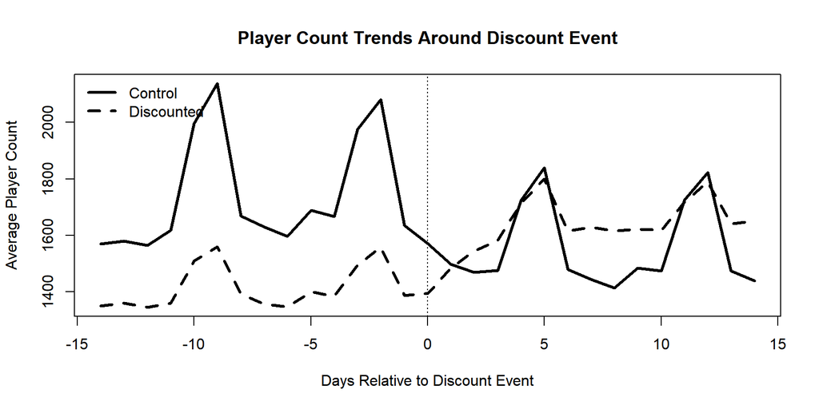

## DID Result

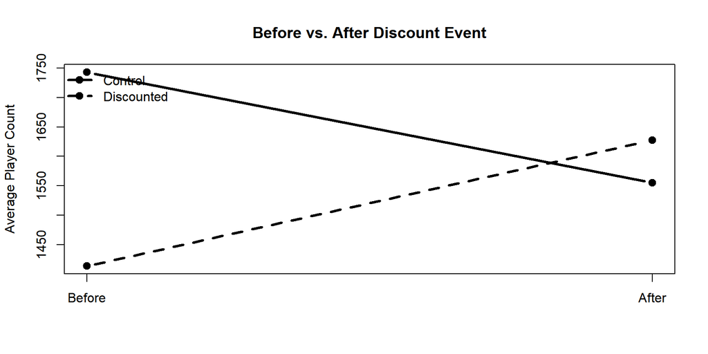

### Estimated Effect

- Raw DID effect: **402.2 players**
- Regression DID effect: **64.6%**
- p-value: **<0.001**

## Marketing Implications

### Recommendation 1

Use discounts as an engagement tool, not only a sales tool.

### Recommendation 2

Prioritize discounts for games with an existing player base that can be reactivated.

### Recommendation 3

Coordinate discounts with marketing campaigns, content updates, or community events to maximize engagement.

## Conclusion

### Key Takeaway

Steam discounts appear to meaningfully increase player engagement in the short run.

Matched DID helps separate the discount effect from pre-existing game popularity.

### Final point

Discounts should be evaluated not only by revenue impact, but also by their ability to reactivate players and increase platform engagement.